### multiple linear regression analysis

```
library(car)
library(mice)
library(gvlma)
library(glmnet)
library(caret)

car：迴歸應用套件
mice：資料模擬使用
gvlma：使用驗證模型假設
glmnet：正則化線性模型擬合套件
caret：整合分類與迴歸模型的強大訓練框架
```

迴歸是預測分析方法之一，以下使用的資料集( Cars93_1.csv )來自 [R Data Mining Blueprints](https://www.packtpub.com/big-data-and-business-intelligence/r-data-mining-blueprints) 書中，不過在流程上我做了一些調整，在 missing values 處理上，書中直接將出現 NA 值的欄位( Rear.seat.room, Luggage.room )移除，調整後的作法是欄位保留，對 NA 值進行三種比較處理( removing, simulating and mean )，另外，加入模型假設檢查、交叉驗證及 Regularization (正則化)，下圖是流程差異比較…

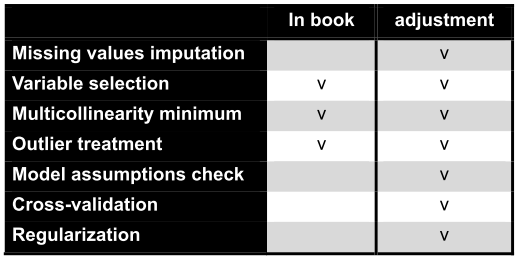

Cars93_1 是有關汽車規格相關資訊，資料筆數與結構如下，目標是利用這些 independent variables 進行 MPG.Overall (每加侖里程數) 的預測

```
## 'data.frame':    93 obs. of  14 variables:
##  $ MPG.Overall       : num  28 21.5 23 22.5 26 26.5 23.5 20.5 23 20.5 ...
##  $ Price             : num  15.9 33.9 29.1 37.7 30 15.7 20.8 23.7 26.3 34.7 ...
##  $ EngineSize        : num  1.8 3.2 2.8 2.8 3.5 2.2 3.8 5.7 3.8 4.9 ...
##  $ Horsepower        : int  140 200 172 172 208 110 170 180 170 200 ...
##  $ RPM               : int  6300 5500 5500 5500 5700 5200 4800 4000 4800 4100 ...
##  $ Rev.per.mile      : int  2890 2335 2280 2535 2545 2565 1570 1320 1690 1510 ...
##  $ Fuel.tank.capacity: num  13.2 18 16.9 21.1 21.1 16.4 18 23 18.8 18 ...
##  $ Length            : int  177 195 180 193 186 189 200 216 198 206 ...
##  $ Wheelbase         : int  102 115 102 106 109 105 111 116 108 114 ...
##  $ Width             : int  68 71 67 70 69 69 74 78 73 73 ...
##  $ Turn.circle       : int  37 38 37 37 39 41 42 45 41 43 ...
##  $ Rear.seat.room    : num  26.5 30 28 31 27 28 30.5 30.5 26.5 35 ...
##  $ Luggage.room      : int  11 15 14 17 13 16 17 21 14 18 ...
##  $ Weight            : int  2705 3560 3375 3405 3640 2880 3470 4105 3495 3620 ...
```

#### **Missing values imputation**

首先是 Missing Values 的處理，利用 mice 套件 md.pattern 方法，先過濾出哪些欄位有出現 NA 值。由以下報表可看出，Rear.seat.room 欄位出現 NA 值2次，Luggage.room 欄位出現11次，接著使用3種方法處理與比較

```r
# verify missing values
md.pattern(Cars93_1)
```

```
##    MPG.Overall Price EngineSize Horsepower RPM Rev.per.mile
## 82           1     1          1          1   1            1
##  9           1     1          1          1   1            1
##  2           1     1          1          1   1            1
##              0     0          0          0   0            0
##    Fuel.tank.capacity Length Wheelbase Width Turn.circle Weight
## 82                  1      1         1     1           1      1
##  9                  1      1         1     1           1      1
##  2                  1      1         1     1           1      1
##                     0      0         0     0           0      0
##    Rear.seat.room Luggage.room
## 82              1            1  0
##  9              1            0  1
##  2              0            0  2
##                 2           11 13
```

方法A：刪除。將有出現 NA 值的資料筆數直接 remove

```r
# remove
Cars93_1.naomit <- subset(Cars93_1, Cars93_1$Rear.seat.room != complete.cases(Cars93_1$Rear.seat.room))
Cars93_1.naomit <- subset(Cars93_1.naomit, Cars93_1.naomit$Luggage.room != complete.cases(Cars93_1.naomit$Luggage.room))
# 同上
#Cars93_1.naomit <- na.omit(Cars93_1)
```

方法B：模擬。利用 mice 套件方法進行資料模擬來代替 NA 值，這裡使用隨機森林、迭代5次的作法，下圖紅色線條是模擬數據，藍色是實際數據(若兩者差異太大，表示不可靠)

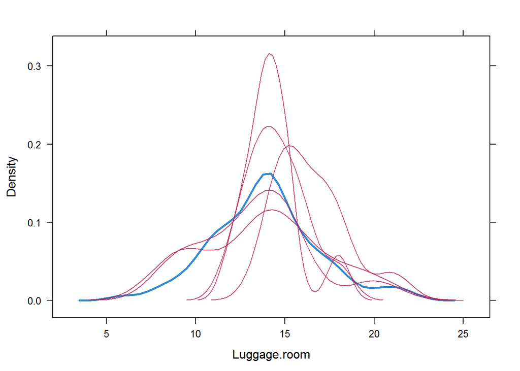

```r
# simulate
set.seed(777)
simulation <- mice(Cars93_1, method = "rf", maxit = 5, printFlag = F)
densityplot(simulation)
Cars93_1.simulate <- complete(simulation, action =1)
```

方法C：平均。用變數欄位的平均值來代替NA值

```r
# mean
Cars93_1.mean <- Cars93_1
Cars93_1.mean$Rear.seat.room[is.na(Cars93_1.mean$Rear.seat.room)] <-
  mean(Cars93_1.mean$Rear.seat.room, na.rm = T)
Cars93_1.mean$Luggage.room[is.na(Cars93_1.mean$Luggage.room)] <-
  mean(Cars93_1.mean$Luggage.room, na.rm = T)
```

首先使用所有 independent variables 進行線性迴歸，初步了解比較一下這三種作法的R<sup>2</sup>值。方法A得到的R<sup>2</sup>為0.7533392，表示這個 model 可準確預測75.33%的輸入值，方法B和方法C得到的R<sup>2</sup>很相近，分別為0.7841793和0.783704，方法B的R<sup>2</sup>是三者中最高的，通常R<sup>2</sup>若大於0.8，可視為好的迴歸 model

```r
# multiple linear regression model(多元線性迴歸)
lm.naomit <- lm(MPG.Overall ~ ., data = Cars93_1.naomit)
lm.simulate <- lm(MPG.Overall ~ ., data = Cars93_1.simulate)
lm.mean <- lm(MPG.Overall ~ ., data = Cars93_1.mean)

summary(lm.naomit)$r.squared
summary(lm.simulate)$r.squared
summary(lm.mean)$r.squared
```

```
## [1] 0.7533392
```

```
## [1] 0.7841793
```

```
## [1] 0.783704
```

#### **Variable selection**

在面臨眾多變數時，自動選擇是不錯的作法，step 語法可設定 forward, backward or both 方式，根據 Akaike Information Criteria (AIC, 赤池信息量準則)逐步產出適當的變數，直到 AIC 最小化即是最後的 model。不過，由於此案例的 independent variables 很少(只有13個)，這裡採用手動挑選的作法，根據 analysis of variance (ANOVA)查看每一個 independent variables 對 MPG.Overall 是否有顯著的貢獻，出現星號表示有，沒有出現星號的變數則不採用

```r
# analysis of variance (ANOVA)
summary.aov(lm.naomit)
```

```
##                    Df Sum Sq Mean Sq F value   Pr(>F)
## Price               1  885.7   885.7 110.224 7.20e-16 ***
## EngineSize          1  369.3   369.3  45.959 3.54e-09 ***
## Horsepower          1   37.4    37.4   4.656  0.03449 *
## RPM                 1   38.8    38.8   4.827  0.03143 *
## Rev.per.mile        1   71.3    71.3   8.877  0.00400 **
## Fuel.tank.capacity  1  147.0   147.0  18.295 6.05e-05 ***
## Length              1    1.6     1.6   0.203  0.65392
## Wheelbase           1   35.0    35.0   4.354  0.04066 *
## Width               1    9.1     9.1   1.139  0.28969
## Turn.circle         1    0.5     0.5   0.060  0.80774
## Rear.seat.room      1    0.6     0.6   0.071  0.79032
## Luggage.room        1    9.1     9.1   1.129  0.29170
## Weight              1   63.4    63.4   7.890  0.00648 **
## Residuals          68  546.4     8.0
## ---
## Signif. codes:  0 '***' 0.001 '**' 0.01 '*' 0.05 '.' 0.1 ' ' 1
```

```r
lm.naomit.aov <-
  update(lm.naomit, . ~ . - Length - Width - Turn.circle - Rear.seat.room - Luggage.room)

summary.aov(lm.simulate)
```

```
##                    Df Sum Sq Mean Sq F value   Pr(>F)
## Price               1  921.8   921.8 125.843  < 2e-16 ***
## EngineSize          1  450.7   450.7  61.528 1.75e-11 ***
## Horsepower          1   35.5    35.5   4.848 0.030603 *
## RPM                 1  134.7   134.7  18.393 5.04e-05 ***
## Rev.per.mile        1   65.8    65.8   8.987 0.003635 **
## Fuel.tank.capacity  1  346.9   346.9  47.360 1.26e-09 ***
## Length              1    0.5     0.5   0.063 0.802023
## Wheelbase           1    0.4     0.4   0.057 0.811715
## Width               1    7.1     7.1   0.972 0.327097
## Turn.circle         1    6.8     6.8   0.934 0.336838
## Rear.seat.room      1    4.2     4.2   0.577 0.449870
## Luggage.room        1   31.7    31.7   4.334 0.040603 *
## Weight              1   96.3    96.3  13.149 0.000508 ***
## Residuals          79  578.7     7.3
## ---
## Signif. codes:  0 '***' 0.001 '**' 0.01 '*' 0.05 '.' 0.1 ' ' 1
```

```r
lm.simulate.aov <-
  update(lm.simulate, . ~ . - Length - Wheelbase - Width - Turn.circle - Rear.seat.room)

summary.aov(lm.mean)
```

```
##                    Df Sum Sq Mean Sq F value   Pr(>F)
## Price               1  921.8   921.8 125.567  < 2e-16 ***
## EngineSize          1  450.7   450.7  61.393 1.82e-11 ***
## Horsepower          1   35.5    35.5   4.837 0.030781 *
## RPM                 1  134.7   134.7  18.353 5.13e-05 ***
## Rev.per.mile        1   65.8    65.8   8.967 0.003670 **
## Fuel.tank.capacity  1  346.9   346.9  47.256 1.30e-09 ***
## Length              1    0.5     0.5   0.063 0.802237
## Wheelbase           1    0.4     0.4   0.057 0.811918
## Width               1    7.1     7.1   0.970 0.327626
## Turn.circle         1    6.8     6.8   0.932 0.337367
## Rear.seat.room      1    5.0     5.0   0.685 0.410307
## Luggage.room        1   25.3    25.3   3.440 0.067362 .
## Weight              1  100.7   100.7  13.721 0.000391 ***
## Residuals          79  579.9     7.3
## ---
## Signif. codes:  0 '***' 0.001 '**' 0.01 '*' 0.05 '.' 0.1 ' ' 1
```

```r
lm.mean.aov <-
  update(lm.mean, . ~ . - Length - Wheelbase - Width - Turn.circle - Rear.seat.room - Luggage.room)
```

經由手動挑選 independent variables 進行線性迴歸所得的R<sup>2</sup>，由於 model 能判別的資訊減少了，因此普遍都下修了一點，方法A得到的R<sup>2</sup>為0.7433961，方法B和方法C分別為0.7663108、0.7570193，不過性能和準度本來就是一個權衡的過程，儘管R<sup>2</sup>略減一些，但三種作法分別減少了5個、5個及6個變數

```r
summary(lm.naomit.aov)$r.squared
summary(lm.simulate.aov)$r.squared
summary(lm.mean.aov)$r.squared
```

```
## [1] 0.7433961
```

```
## [1] 0.7663108
```

```
## [1] 0.7570193
```

#### **Multicollinearity minimum**

線性迴歸的基本假設之一，independent variables 之間的相關性應為0或最小化。Variance Inflation Factor (VIF, 變異數膨脹因子)可用來判斷 multicollinearity (多重共線性)，VIF 值大於10表示有強烈可能是多重共線性， 作法上是從最大者開始刪除，一次刪一個，之後檢測、再重複執行，直到 VIF 值都小於10。利用 car 套件 vif 方法可進行檢測

```r
# 多重共線性最小化
vif(lm.naomit.aov)
```

```
##              Price         EngineSize         Horsepower
##           3.012489          15.901591          13.566903
##                RPM       Rev.per.mile Fuel.tank.capacity
##           4.462154           3.842992           5.962003
##          Wheelbase             Weight
##           6.419590          22.717728
```

```r
lm.naomit.aov2 <- update(lm.naomit.aov, .~. -Weight)
vif(lm.naomit.aov2)
```

```
##              Price         EngineSize         Horsepower
##           2.999104          15.785920           9.292943
##                RPM       Rev.per.mile Fuel.tank.capacity
##           3.925853           3.416073           4.449275
##          Wheelbase
##           4.761536
```

```r
lm.naomit.aov3 <- update(lm.naomit.aov2, .~. -EngineSize)
vif(lm.naomit.aov3)
```

```
##              Price         Horsepower                RPM
##           2.978838           5.339622           1.983546
##       Rev.per.mile Fuel.tank.capacity          Wheelbase
##           3.124715           4.331032           3.852041
```

```r
vif(lm.simulate.aov)
```

```
##              Price         EngineSize         Horsepower
##           2.894046          10.058812           8.454704
##                RPM       Rev.per.mile Fuel.tank.capacity
##           3.867530           3.613897           5.396640
##       Luggage.room             Weight
##           1.825081           8.410892
```

```r
lm.simulate.aov2 <- update(lm.simulate.aov, .~. -EngineSize)
vif(lm.simulate.aov2)
```

```
##              Price         Horsepower                RPM
##           2.893916           5.631466           2.377776
##       Rev.per.mile Fuel.tank.capacity       Luggage.room
##           3.310116           5.394796           1.667932
##             Weight
##           8.343089
```

```r
vif(lm.mean.aov)
```

```
##              Price         EngineSize         Horsepower
##           2.849731           9.192694           7.876424
##                RPM       Rev.per.mile Fuel.tank.capacity
##           3.845339           3.487343           5.341663
##             Weight
##           8.406093
```

經由 vif 檢測與調整，三種方法的 models 分別又再減少了2個、1個和0個變數。以上都是針對變數進行篩選調整，接下來針對干擾資料處理…

#### **Outlier treatment**

干擾資料或離群值可能造成 model 結果的偏離，通常離群值被定義為超出1.5倍IQR(四分位差)範圍的數值。car 套件提供 influenceIndexPlot 視覺化方法，根據 Cook’s distances, Studentized residuals …繪出離群資料。以方法A的模型資料為例，標示點設為3個，各指標離群資料如下圖

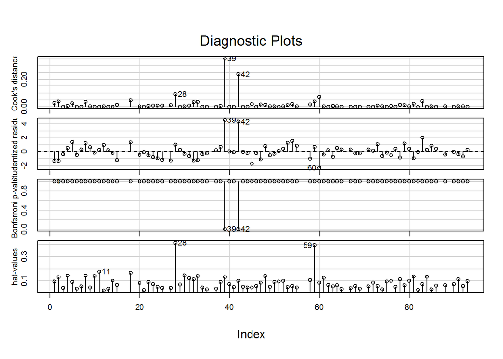

```r
# Index Plots of the influence measures
influenceIndexPlot(lm.naomit.aov3, id.n=3)
```

接著根據方法A、B和C的模型資料，分別將其離群資料一個一個移除並觀察R<sup>2</sup>的 improvement，整體而言，逐步刪除 outliers 有助於R<sup>2</sup>的提升，其中方法B和方法C的 model 經過這一連串的調整，R<sup>2</sup>已經提升至0.81和0.82以上(超越一開始的0.78)

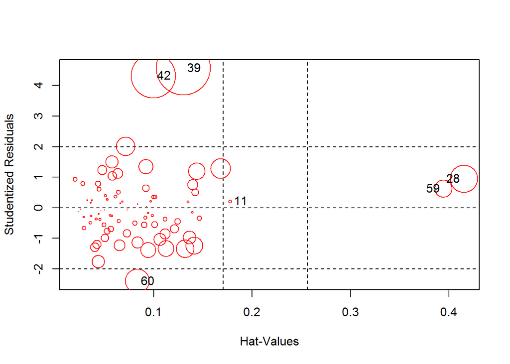

```r
# remove outliers one-by-one and get R^2
outliersRemovingCheck <- function(md, points) {
  df <- md$model
  for (i in 1:length(points)) {
    ps <- points[1:i]
    md.tmp <- update(md, data = df[-ps,])
    r2 <- round(summary(md.tmp)$r.squared, digits = 5)
    print(paste(r2, '------ remove outliers row', paste(ps, collapse = ', ')))
  }
}

# outliers選擇依庫克距離大小排序
outliersIndex <- function(md) {
  inf.point <- influencePlot(md, id.n = 3, col = "red")
  indices <- as.integer(row.names(inf.point)[order(inf.point$CookD, decreasing = T)])
  indices
}

# one-by-one remove outliers and check R^2
indices.naomit <- outliersIndex(lm.naomit.aov3)
```

```r
outliersRemovingCheck(lm.naomit.aov3, indices.naomit)
```

```
## [1] "0.69522 ------ remove outliers row 39"
## [1] "0.69924 ------ remove outliers row 39, 42"
## [1] "0.70751 ------ remove outliers row 39, 42, 28"
## [1] "0.70811 ------ remove outliers row 39, 42, 28, 60"
## [1] "0.70704 ------ remove outliers row 39, 42, 28, 60, 59"
## [1] "0.70211 ------ remove outliers row 39, 42, 28, 60, 59, 11"
```

```r
indices.simulate <- outliersIndex(lm.simulate.aov2)
```

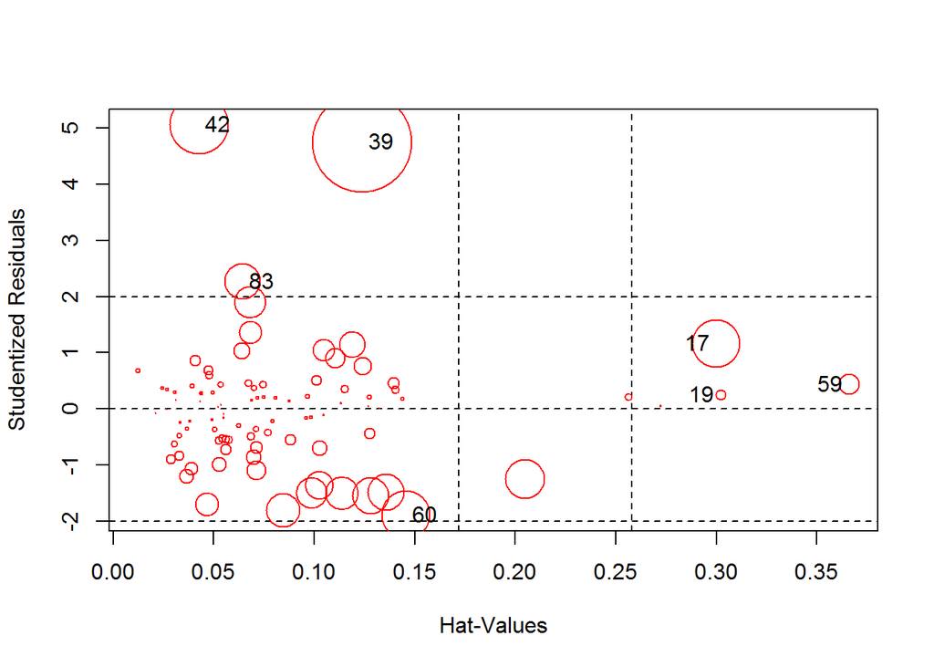

```r
outliersRemovingCheck(lm.simulate.aov2, indices.simulate)
```

```
## [1] "0.75795 ------ remove outliers row 39"
## [1] "0.80148 ------ remove outliers row 39, 42"
## [1] "0.81314 ------ remove outliers row 39, 42, 60"
## [1] "0.80996 ------ remove outliers row 39, 42, 60, 17"
## [1] "0.81537 ------ remove outliers row 39, 42, 60, 17, 83"
## [1] "0.81487 ------ remove outliers row 39, 42, 60, 17, 83, 59"
## [1] "0.81278 ------ remove outliers row 39, 42, 60, 17, 83, 59, 19"
```

```r
indices.mean <- outliersIndex(lm.mean.aov)
```

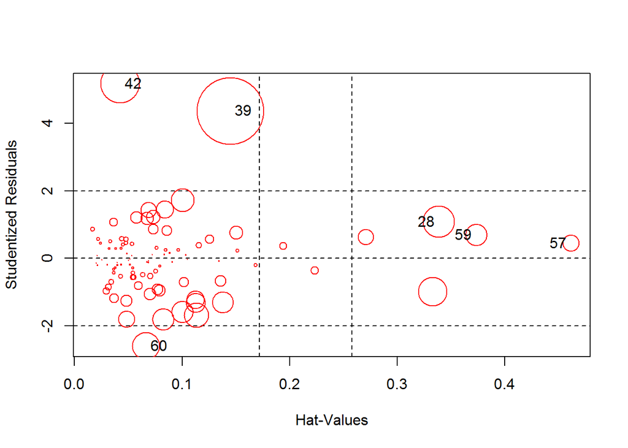

```r
outliersRemovingCheck(lm.mean.aov, indices.mean)
```

```
## [1] "0.75634 ------ remove outliers row 39"
## [1] "0.79994 ------ remove outliers row 39, 42"
## [1] "0.80082 ------ remove outliers row 39, 42, 28"
## [1] "0.82246 ------ remove outliers row 39, 42, 28, 60"
## [1] "0.82263 ------ remove outliers row 39, 42, 28, 60, 59"
## [1] "0.82265 ------ remove outliers row 39, 42, 28, 60, 59, 57"
```

根據以上的 improvement，刪除各模型資料的離群值並 update models，更新後方法A模型的R<sup>2</sup>為0.7021103，方法B模型R<sup>2</sup>為0.8127756，方法C模型R<sup>2</sup>為0.8226459，可見方法A直接刪除 NA 值資料的作法不是很好，方法B和方法C的結果比較相近，不過方法C使用平均值來代替 NA 的作法，在此案例資料的表現上R<sup>2</sup>是最高的

```r
# 刪除outliers and update models
Cars93_1.naomit.final <- Cars93_1.naomit[-indices.naomit, ]
Cars93_1.simulate.final <- Cars93_1.simulate[-indices.simulate, ]
Cars93_1.mean.final <- Cars93_1.mean[-indices.mean, ]

lm.naomit.final <- update(lm.naomit.aov3, .~. , data = Cars93_1.naomit.final)
lm.simulate.final <- update(lm.simulate.aov2, .~. , data = Cars93_1.simulate.final)
lm.mean.final <- update(lm.mean.aov, .~. , data = Cars93_1.mean.final)

summary(lm.naomit.final)$r.squared
summary(lm.simulate.final)$r.squared
summary(lm.mean.final)$r.squared
```

```
## [1] 0.7021103
```

```
## [1] 0.8127756
```

```
## [1] 0.8226459
```

#### **Model assumptions check**

線性迴歸的基本假設，除了之前提的 multicollinearity (多重共線性)最小化，殘差也應服從常態分配…等，car 套件的 qqPlot 方法可幫助檢視殘差分佈，資料點如果都落在對角線上，表示資料呈現完美的常態分配，透過繪製的Q-Q圖( Quantile-Quantile )可看出，方法B和方法C的 model 表現比較好

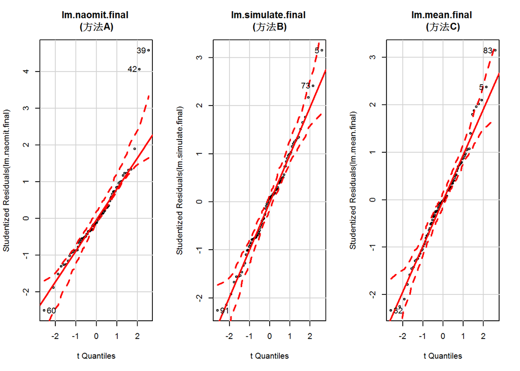

此外，gvlma 套件方法也提供快速驗證假設，以本次實驗結果R<sup>2</sup>最佳之方法C的 model 為例，5項假設中有1項假設( Link Function )沒有被滿足，後續還能再 tuning (如果目標是做出好的預測要盡力滿足假設)，即使如此，方法C迴歸模型的係數和R<sup>2</sup>還是具有意義

```r
# 驗證模型假設, 以方法C的model為例
gvlma(lm.mean.final)
```

```
##
## Call:
## lm(formula = MPG.Overall ~ Price + EngineSize + Horsepower +
##     RPM + Rev.per.mile + Fuel.tank.capacity + Weight, data = Cars93_1.mean.final)
##
## Coefficients:
##        (Intercept)               Price          EngineSize
##          29.337513           -0.049445            2.794504
##         Horsepower                 RPM        Rev.per.mile
##          -0.036014            0.002132            0.001718
## Fuel.tank.capacity              Weight
##          -0.596478           -0.003428
##
##
## ASSESSMENT OF THE LINEAR MODEL ASSUMPTIONS
## USING THE GLOBAL TEST ON 4 DEGREES-OF-FREEDOM:
## Level of Significance =  0.05
##
## Call:
##  gvlma(x = lm.mean.final)
##
##                     Value p-value                   Decision
## Global Stat        7.2082 0.12529    Assumptions acceptable.
## Skewness           0.9361 0.33327    Assumptions acceptable.
## Kurtosis           0.3503 0.55397    Assumptions acceptable.
## Link Function      3.9412 0.04712 Assumptions NOT satisfied!
## Heteroscedasticity 1.9806 0.15933    Assumptions acceptable.
```

#### **Cross-validation / Regularization**

到目前為止，方法C的 model 使用變數和資料已經得到，為了避免 overfitting，接下來採用交叉驗證 ( cross-validation, CV )和正則化( Regularization, 同時考慮擬合準確度和模型複雜度)，交叉驗證採用隨機抽樣8:2的訓練/測試資料，正則化使用 glmnet 套件方法，依最小RMSE找出最佳超參數lambda

```r
#訓練/測試資料(80% vs 20%)
set.seed(777)
index <- sample(nrow(Cars93_1.mean.final), 0.8 * nrow(Cars93_1.mean.final))
Cars93_train <- Cars93_1.mean.final[index, c('MPG.Overall', 'Price', 'EngineSize', 'Horsepower',
                                             'RPM', 'Rev.per.mile', 'Fuel.tank.capacity', 'Weight')]
Cars93_test <- Cars93_1.mean.final[-index, c('MPG.Overall', 'Price', 'EngineSize', 'Horsepower',
                                             'RPM', 'Rev.per.mile', 'Fuel.tank.capacity', 'Weight')]
X <- as.matrix(Cars93_train[,-1])
Y <- Cars93_train$MPG.Overall

# Regularization(正則化)
# alpha=1 is the lasso(最小絕對緊縮與選擇算子) penalty
glmnet.fit <- glmnet(X, Y, alpha = 1)
lambdas <- glmnet.fit$lambda

# RMSE
rmse <- function(a, b) {
  return(sqrt(mean((a - b) ^ 2)))
}
# lda performance
performance <- data.frame()
for (lda in lambdas) {
  performance <- rbind(performance,
                       data.frame(Lambda = lda,
                         RMSE = rmse(
                           Cars93_test$MPG.Overall,
                           predict(glmnet.fit, as.matrix(Cars93_test[,-1]), s = lda))))
}
# 最佳Lambda
best.lambda <- with(performance, Lambda[which(RMSE == min(RMSE))])
```

最佳超參數，當 Lambda = 0.1294082 時有最小 RMSE

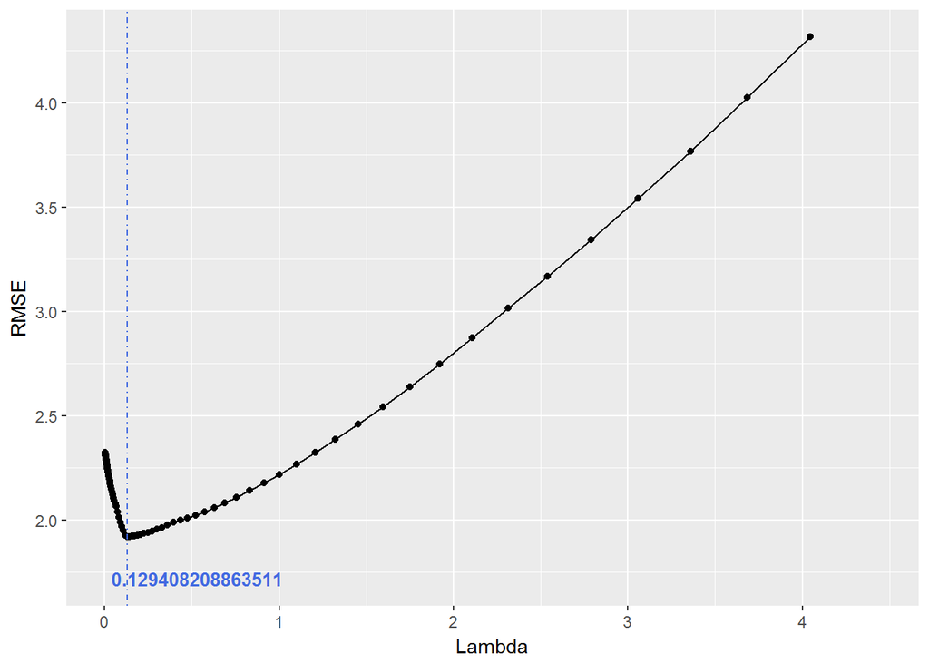

使用最佳 Lambda 值(0.1294082)正則化建立最後的模型，有2變數( EngineSize 和 Horsepower )的係數為0，代表模型複雜度簡化又能保有準確性

```r
# 正則化, 用 best.lambda 擬合建模
Cars93_final <- Cars93_1.mean.final[, c('MPG.Overall', 'Price', 'EngineSize', 'Horsepower',
                             'RPM', 'Rev.per.mile', 'Fuel.tank.capacity', 'Weight')]
glmnet.fit.final <- glmnet(as.matrix(Cars93_final[,-1]), Cars93_final$MPG.Overall, alpha = 1)
coef(glmnet.fit.final, s = best.lambda)
```

```
## 8 x 1 sparse Matrix of class "dgCMatrix"
##                                1
## (Intercept)         4.489850e+01
## Price              -2.943472e-02
## EngineSize          .
## Horsepower          .
## RPM                 7.748416e-05
## Rev.per.mile        2.655754e-04
## Fuel.tank.capacity -4.576998e-01
## Weight             -3.965011e-03
```

caret 套件也有支援 glmnet，可利用來查看最後模型的 performance，順便驗證一下使用最佳 Lambda 超參數的RMSE表現是否有比預設來的好，從下表的結果看起來的確是如此，不過R<sup>2</sup>表現上預設值較佳。anyway， 經由這一連串流程處理，比較了三種方法建模的差異，成功產出最後模型，不但簡化了 model 複雜度(變數由13個降至5個)也改善了R<sup>2</sup>(由0.783704提升至0.8162456)

|  | alpha | lambda | RMSE | Rsquared | RMSESD | RsquaredSD |
| --- | --- | --- | --- | --- | --- | --- |
| 9 | 1 | 0.7962813 | 2.161153 | 0.8211513 | 0.6893705 | 0.1049114 |

| alpha | lambda | RMSE | Rsquared | RMSESD | RsquaredSD |
| --- | --- | --- | --- | --- | --- |
| 1 | 0.1294082 | 2.090282 | 0.8162456 | 0.5850243 | 0.1037916 |

### Lessons Learned:

#### Linear regression

#### Variable selection

#### Multicollinearity

#### Regularization